# Risk Factor Analysis

## Outcome Variable

**Outcome Variable:** stunted

## Predictor Variables

**Intervention Variable:** pers_wast

**Adjustment Set:**

- arm
- sex
- W_mage
- meducyrs
- month
- brthmon
- delta_W_mage
- delta_meducyrs
- delta_month
- delta_brthmon

## Stratifying Variables

The analysis was stratified on these variable(s):

- agecat
- studyid
- country

## Data Summary

| agecat | studyid | country | pers_wast | stunted | n_cell | n |
| --- | --- | --- | --- | --- | --- | --- |
| Birth | ki0047075b-MAL-ED | BANGLADESH | 0 | 0 | 203 | 255 |
| Birth | ki0047075b-MAL-ED | BANGLADESH | 0 | 1 | 43 | 255 |
| Birth | ki0047075b-MAL-ED | BANGLADESH | 1 | 0 | 7 | 255 |
| Birth | ki0047075b-MAL-ED | BANGLADESH | 1 | 1 | 2 | 255 |
| Birth | ki0047075b-MAL-ED | BRAZIL | 0 | 0 | 170 | 191 |
| Birth | ki0047075b-MAL-ED | BRAZIL | 0 | 1 | 21 | 191 |
| Birth | ki0047075b-MAL-ED | BRAZIL | 1 | 0 | 0 | 191 |
| Birth | ki0047075b-MAL-ED | BRAZIL | 1 | 1 | 0 | 191 |
| Birth | ki0047075b-MAL-ED | INDIA | 0 | 0 | 159 | 206 |
| Birth | ki0047075b-MAL-ED | INDIA | 0 | 1 | 32 | 206 |
| Birth | ki0047075b-MAL-ED | INDIA | 1 | 0 | 14 | 206 |
| Birth | ki0047075b-MAL-ED | INDIA | 1 | 1 | 1 | 206 |
| Birth | ki0047075b-MAL-ED | NEPAL | 0 | 0 | 152 | 173 |
| Birth | ki0047075b-MAL-ED | NEPAL | 0 | 1 | 18 | 173 |
| Birth | ki0047075b-MAL-ED | NEPAL | 1 | 0 | 3 | 173 |
| Birth | ki0047075b-MAL-ED | NEPAL | 1 | 1 | 0 | 173 |
| Birth | ki0047075b-MAL-ED | PERU | 0 | 0 | 253 | 286 |
| Birth | ki0047075b-MAL-ED | PERU | 0 | 1 | 33 | 286 |
| Birth | ki0047075b-MAL-ED | PERU | 1 | 0 | 0 | 286 |
| Birth | ki0047075b-MAL-ED | PERU | 1 | 1 | 0 | 286 |
| Birth | ki0047075b-MAL-ED | SOUTH AFRICA | 0 | 0 | 228 | 261 |
| Birth | ki0047075b-MAL-ED | SOUTH AFRICA | 0 | 1 | 27 | 261 |
| Birth | ki0047075b-MAL-ED | SOUTH AFRICA | 1 | 0 | 6 | 261 |
| Birth | ki0047075b-MAL-ED | SOUTH AFRICA | 1 | 1 | 0 | 261 |
| Birth | ki0047075b-MAL-ED | TANZANIA, UNITED REPUBLIC OF | 0 | 0 | 105 | 123 |
| Birth | ki0047075b-MAL-ED | TANZANIA, UNITED REPUBLIC OF | 0 | 1 | 18 | 123 |
| Birth | ki0047075b-MAL-ED | TANZANIA, UNITED REPUBLIC OF | 1 | 0 | 0 | 123 |
| Birth | ki0047075b-MAL-ED | TANZANIA, UNITED REPUBLIC OF | 1 | 1 | 0 | 123 |
| Birth | ki1000108-CMC-V-BCS-2002 | INDIA | 0 | 0 | 67 | 90 |
| Birth | ki1000108-CMC-V-BCS-2002 | INDIA | 0 | 1 | 11 | 90 |

[output cut: 170 more lines]

The following strata were considered:

- agecat: 24 months, studyid: ki0047075b-MAL-ED, country: BANGLADESH
- agecat: 24 months, studyid: ki0047075b-MAL-ED, country: BRAZIL
- agecat: 24 months, studyid: ki0047075b-MAL-ED, country: INDIA
- agecat: 24 months, studyid: ki0047075b-MAL-ED, country: NEPAL
- agecat: 24 months, studyid: ki0047075b-MAL-ED, country: PERU
- agecat: 24 months, studyid: ki0047075b-MAL-ED, country: SOUTH AFRICA
- agecat: 24 months, studyid: ki0047075b-MAL-ED, country: TANZANIA, UNITED REPUBLIC OF
- agecat: 24 months, studyid: ki1000108-CMC-V-BCS-2002, country: INDIA
- agecat: 24 months, studyid: ki1000108-IRC, country: INDIA
- agecat: 24 months, studyid: ki1017093b-PROVIDE, country: BANGLADESH
- agecat: 24 months, studyid: ki1066203-TanzaniaChild2, country: TANZANIA, UNITED REPUBLIC OF
- agecat: 24 months, studyid: ki1101329-Keneba, country: GAMBIA
- agecat: 24 months, studyid: ki1113344-GMS-Nepal, country: NEPAL
- agecat: 24 months, studyid: ki1114097-CMIN, country: BANGLADESH
- agecat: 24 months, studyid: ki1114097-CMIN, country: PERU
- agecat: 24 months, studyid: ki1114097-CONTENT, country: PERU
- agecat: 6 months, studyid: ki0047075b-MAL-ED, country: BANGLADESH
- agecat: 6 months, studyid: ki0047075b-MAL-ED, country: BRAZIL
- agecat: 6 months, studyid: ki0047075b-MAL-ED, country: INDIA
- agecat: 6 months, studyid: ki0047075b-MAL-ED, country: NEPAL
- agecat: 6 months, studyid: ki0047075b-MAL-ED, country: PERU
- agecat: 6 months, studyid: ki0047075b-MAL-ED, country: SOUTH AFRICA
- agecat: 6 months, studyid: ki0047075b-MAL-ED, country: TANZANIA, UNITED REPUBLIC OF
- agecat: 6 months, studyid: ki1000108-CMC-V-BCS-2002, country: INDIA
- agecat: 6 months, studyid: ki1000108-IRC, country: INDIA
- agecat: 6 months, studyid: ki1000109-EE, country: PAKISTAN
- agecat: 6 months, studyid: ki1000109-ResPak, country: PAKISTAN
- agecat: 6 months, studyid: ki1017093b-PROVIDE, country: BANGLADESH
- agecat: 6 months, studyid: ki1066203-TanzaniaChild2, country: TANZANIA, UNITED REPUBLIC OF
- agecat: 6 months, studyid: ki1101329-Keneba, country: GAMBIA
- agecat: 6 months, studyid: ki1112895-Guatemala BSC, country: GUATEMALA
- agecat: 6 months, studyid: ki1113344-GMS-Nepal, country: NEPAL
- agecat: 6 months, studyid: ki1114097-CMIN, country: BANGLADESH
- agecat: 6 months, studyid: ki1114097-CMIN, country: PERU
- agecat: 6 months, studyid: ki1114097-CONTENT, country: PERU
- agecat: Birth, studyid: ki0047075b-MAL-ED, country: BANGLADESH
- agecat: Birth, studyid: ki0047075b-MAL-ED, country: BRAZIL
- agecat: Birth, studyid: ki0047075b-MAL-ED, country: INDIA
- agecat: Birth, studyid: ki0047075b-MAL-ED, country: NEPAL
- agecat: Birth, studyid: ki0047075b-MAL-ED, country: PERU
- agecat: Birth, studyid: ki0047075b-MAL-ED, country: SOUTH AFRICA
- agecat: Birth, studyid: ki0047075b-MAL-ED, country: TANZANIA, UNITED REPUBLIC OF
- agecat: Birth, studyid: ki1000108-CMC-V-BCS-2002, country: INDIA
- agecat: Birth, studyid: ki1000108-IRC, country: INDIA
- agecat: Birth, studyid: ki1000109-EE, country: PAKISTAN
- agecat: Birth, studyid: ki1000109-ResPak, country: PAKISTAN
- agecat: Birth, studyid: ki1101329-Keneba, country: GAMBIA
- agecat: Birth, studyid: ki1114097-CMIN, country: BANGLADESH
- agecat: Birth, studyid: ki1114097-CMIN, country: PERU
- agecat: Birth, studyid: ki1114097-CONTENT, country: PERU

### Dropped Strata

Some strata were dropped due to rare outcomes:

- agecat: Birth, studyid: ki0047075b-MAL-ED, country: BANGLADESH
- agecat: Birth, studyid: ki0047075b-MAL-ED, country: BRAZIL
- agecat: Birth, studyid: ki0047075b-MAL-ED, country: INDIA
- agecat: Birth, studyid: ki0047075b-MAL-ED, country: NEPAL
- agecat: Birth, studyid: ki0047075b-MAL-ED, country: PERU
- agecat: Birth, studyid: ki0047075b-MAL-ED, country: SOUTH AFRICA
- agecat: Birth, studyid: ki0047075b-MAL-ED, country: TANZANIA, UNITED REPUBLIC OF
- agecat: Birth, studyid: ki1000109-EE, country: PAKISTAN
- agecat: Birth, studyid: ki1000109-ResPak, country: PAKISTAN
- agecat: Birth, studyid: ki1101329-Keneba, country: GAMBIA
- agecat: Birth, studyid: ki1114097-CMIN, country: BANGLADESH
- agecat: Birth, studyid: ki1114097-CMIN, country: PERU
- agecat: Birth, studyid: ki1114097-CONTENT, country: PERU
- agecat: 6 months, studyid: ki0047075b-MAL-ED, country: BANGLADESH
- agecat: 6 months, studyid: ki0047075b-MAL-ED, country: BRAZIL
- agecat: 6 months, studyid: ki0047075b-MAL-ED, country: INDIA
- agecat: 6 months, studyid: ki0047075b-MAL-ED, country: NEPAL
- agecat: 6 months, studyid: ki0047075b-MAL-ED, country: PERU
- agecat: 6 months, studyid: ki0047075b-MAL-ED, country: SOUTH AFRICA
- agecat: 6 months, studyid: ki0047075b-MAL-ED, country: TANZANIA, UNITED REPUBLIC OF
- agecat: 6 months, studyid: ki1066203-TanzaniaChild2, country: TANZANIA, UNITED REPUBLIC OF
- agecat: 6 months, studyid: ki1112895-Guatemala BSC, country: GUATEMALA
- agecat: 6 months, studyid: ki1114097-CMIN, country: BANGLADESH
- agecat: 6 months, studyid: ki1114097-CONTENT, country: PERU
- agecat: 24 months, studyid: ki0047075b-MAL-ED, country: BANGLADESH
- agecat: 24 months, studyid: ki0047075b-MAL-ED, country: BRAZIL
- agecat: 24 months, studyid: ki0047075b-MAL-ED, country: INDIA
- agecat: 24 months, studyid: ki0047075b-MAL-ED, country: NEPAL
- agecat: 24 months, studyid: ki0047075b-MAL-ED, country: PERU
- agecat: 24 months, studyid: ki0047075b-MAL-ED, country: SOUTH AFRICA
- agecat: 24 months, studyid: ki0047075b-MAL-ED, country: TANZANIA, UNITED REPUBLIC OF
- agecat: 24 months, studyid: ki1017093b-PROVIDE, country: BANGLADESH
- agecat: 24 months, studyid: ki1066203-TanzaniaChild2, country: TANZANIA, UNITED REPUBLIC OF
- agecat: 24 months, studyid: ki1114097-CMIN, country: BANGLADESH
- agecat: 24 months, studyid: ki1114097-CMIN, country: PERU
- agecat: 24 months, studyid: ki1114097-CONTENT, country: PERU

## Methods Detail

We’re interested in the causal parameters $E[Y_a]$ for all values of $a \in \mathcal{A}$. These parameters represent the mean outcome if, possibly contrary to fact, we intervened to set all units to have $A=a$. Under the randomization and positivity assumptions, these are identified by the statistical parameters $\psi_a=E_W[E_{Y|A,W}(Y|A=a,W)]$. In addition, we’re interested in the mean of $Y$, $E[Y]$ under no intervention (the observed mean). We will estimate these parameters by using SuperLearner to fit the relevant likelihood factors – $E_{Y|A,W}(Y|A=a,W)$ and $p(A=a|W)$, and then updating our likelihood fit using a joint TMLE.

For unadjusted analyses ($W=\{\}$), initial likelihoods were estimated using Lrnr_glm to estimate the simple $E(Y|A)$ and Lrnr_mean to estimate $p(A)$. For adjusted analyses, a small library containing Lrnr_glmnet, Lrnr_xgboost, and Lrnr_mean was used.

Having estimated these parameters, we will then use the delta method to estimate relative risks and attributable risks relative to a prespecified baseline level of $A$.

# Results Detail

## Results Plots

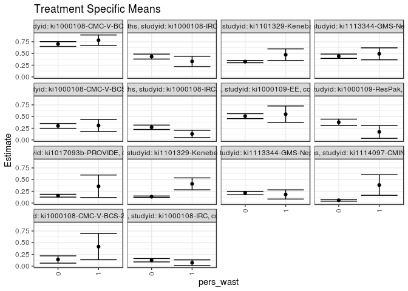

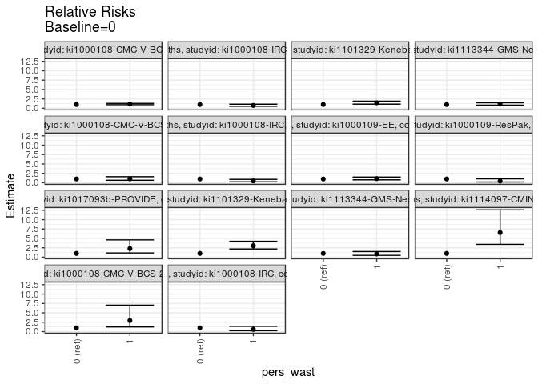

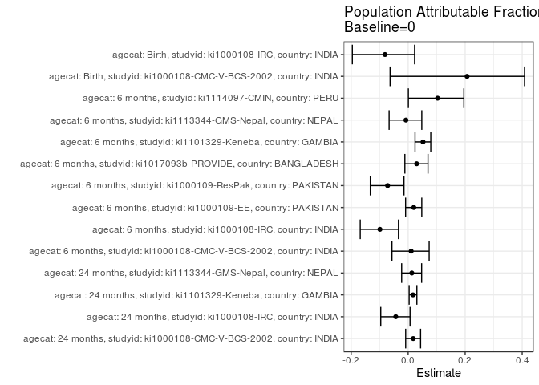

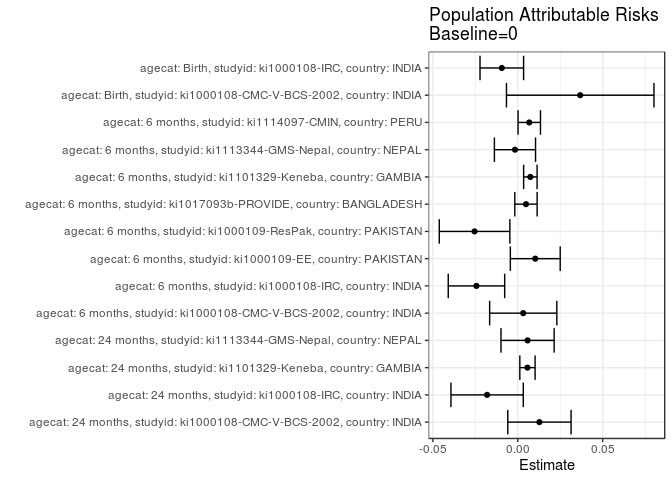

## Results Table

### Parameter: TSM

| agecat | studyid | country | intervention_level | baseline_level | estimate | ci_lower | ci_upper |
| --- | --- | --- | --- | --- | --- | --- | --- |
| Birth | ki1000108-CMC-V-BCS-2002 | INDIA | 0 | NA | 0.1410256 | 0.0633533 | 0.2186979 |
| Birth | ki1000108-CMC-V-BCS-2002 | INDIA | 1 | NA | 0.4166667 | 0.1361643 | 0.6971690 |
| Birth | ki1000108-IRC | INDIA | 0 | NA | 0.1253918 | 0.0890042 | 0.1617795 |
| Birth | ki1000108-IRC | INDIA | 1 | NA | 0.0724638 | 0.0112132 | 0.1337143 |
| 6 months | ki1000108-CMC-V-BCS-2002 | INDIA | 0 | NA | 0.3000733 | 0.2490896 | 0.3510570 |
| 6 months | ki1000108-CMC-V-BCS-2002 | INDIA | 1 | NA | 0.3088915 | 0.1809085 | 0.4368744 |
| 6 months | ki1000108-IRC | INDIA | 0 | NA | 0.2700297 | 0.2225699 | 0.3174894 |
| 6 months | ki1000108-IRC | INDIA | 1 | NA | 0.1285714 | 0.0500621 | 0.2070808 |
| 6 months | ki1000109-EE | PAKISTAN | 0 | NA | 0.5085239 | 0.4556142 | 0.5614335 |
| 6 months | ki1000109-EE | PAKISTAN | 1 | NA | 0.5502910 | 0.3747240 | 0.7258579 |
| 6 months | ki1000109-ResPak | PAKISTAN | 0 | NA | 0.3786408 | 0.3122626 | 0.4450190 |
| 6 months | ki1000109-ResPak | PAKISTAN | 1 | NA | 0.1724138 | 0.0346396 | 0.3101879 |
| 6 months | ki1017093b-PROVIDE | BANGLADESH | 0 | NA | 0.1564148 | 0.1265123 | 0.1863172 |
| 6 months | ki1017093b-PROVIDE | BANGLADESH | 1 | NA | 0.3571429 | 0.1158444 | 0.5984413 |
| 6 months | ki1101329-Keneba | GAMBIA | 0 | NA | 0.1345516 | 0.1195920 | 0.1495111 |
| 6 months | ki1101329-Keneba | GAMBIA | 1 | NA | 0.4094844 | 0.2819922 | 0.5369766 |
| 6 months | ki1113344-GMS-Nepal | NEPAL | 0 | NA | 0.2130258 | 0.1769627 | 0.2490890 |
| 6 months | ki1113344-GMS-Nepal | NEPAL | 1 | NA | 0.1830607 | 0.0852975 | 0.2808239 |
| 6 months | ki1114097-CMIN | PERU | 0 | NA | 0.0586319 | 0.0399529 | 0.0773109 |
| 6 months | ki1114097-CMIN | PERU | 1 | NA | 0.3846154 | 0.1651099 | 0.6041209 |
| 24 months | ki1000108-CMC-V-BCS-2002 | INDIA | 0 | NA | 0.7019289 | 0.6509880 | 0.7528698 |
| 24 months | ki1000108-CMC-V-BCS-2002 | INDIA | 1 | NA | 0.7837005 | 0.6722416 | 0.8951594 |
| 24 months | ki1000108-IRC | INDIA | 0 | NA | 0.4337040 | 0.3808513 | 0.4865566 |
| 24 months | ki1000108-IRC | INDIA | 1 | NA | 0.3302397 | 0.2191838 | 0.4412956 |
| 24 months | ki1101329-Keneba | GAMBIA | 0 | NA | 0.3261505 | 0.3024656 | 0.3498355 |
| 24 months | ki1101329-Keneba | GAMBIA | 1 | NA | 0.4732101 | 0.3483019 | 0.5981183 |
| 24 months | ki1113344-GMS-Nepal | NEPAL | 0 | NA | 0.4411407 | 0.3946951 | 0.4875862 |
| 24 months | ki1113344-GMS-Nepal | NEPAL | 1 | NA | 0.4925893 | 0.3648783 | 0.6203003 |

### Parameter: E(Y)

| agecat | studyid | country | intervention_level | baseline_level | estimate | ci_lower | ci_upper |
| --- | --- | --- | --- | --- | --- | --- | --- |
| Birth | ki1000108-CMC-V-BCS-2002 | INDIA | NA | NA | 0.1777778 | 0.0983474 | 0.2572081 |
| Birth | ki1000108-IRC | INDIA | NA | NA | 0.1159794 | 0.0840777 | 0.1478811 |
| 6 months | ki1000108-CMC-V-BCS-2002 | INDIA | NA | NA | 0.3032787 | 0.2561210 | 0.3504363 |
| 6 months | ki1000108-IRC | INDIA | NA | NA | 0.2457002 | 0.2038248 | 0.2875757 |
| 6 months | ki1000109-EE | PAKISTAN | NA | NA | 0.5188172 | 0.4679751 | 0.5696593 |
| 6 months | ki1000109-ResPak | PAKISTAN | NA | NA | 0.3531915 | 0.2919518 | 0.4144312 |
| 6 months | ki1017093b-PROVIDE | BANGLADESH | NA | NA | 0.1612350 | 0.1313580 | 0.1911120 |
| 6 months | ki1101329-Keneba | GAMBIA | NA | NA | 0.1419543 | 0.1268686 | 0.1570400 |
| 6 months | ki1113344-GMS-Nepal | NEPAL | NA | NA | 0.2113677 | 0.1776128 | 0.2451225 |
| 6 months | ki1114097-CMIN | PERU | NA | NA | 0.0653907 | 0.0460250 | 0.0847565 |
| 24 months | ki1000108-CMC-V-BCS-2002 | INDIA | NA | NA | 0.7146739 | 0.6684741 | 0.7608737 |
| 24 months | ki1000108-IRC | INDIA | NA | NA | 0.4156479 | 0.3678270 | 0.4634689 |
| 24 months | ki1101329-Keneba | GAMBIA | NA | NA | 0.3318414 | 0.3084975 | 0.3551853 |
| 24 months | ki1113344-GMS-Nepal | NEPAL | NA | NA | 0.4468938 | 0.4032281 | 0.4905594 |

### Parameter: RR

| agecat | studyid | country | intervention_level | baseline_level | estimate | ci_lower | ci_upper |
| --- | --- | --- | --- | --- | --- | --- | --- |
| Birth | ki1000108-CMC-V-BCS-2002 | INDIA | 0 | 0 | 1.0000000 | 1.0000000 | 1.000000 |
| Birth | ki1000108-CMC-V-BCS-2002 | INDIA | 1 | 0 | 2.9545455 | 1.2380602 | 7.050820 |
| Birth | ki1000108-IRC | INDIA | 0 | 0 | 1.0000000 | 1.0000000 | 1.000000 |
| Birth | ki1000108-IRC | INDIA | 1 | 0 | 0.5778986 | 0.2364447 | 1.412452 |
| 6 months | ki1000108-CMC-V-BCS-2002 | INDIA | 0 | 0 | 1.0000000 | 1.0000000 | 1.000000 |
| 6 months | ki1000108-CMC-V-BCS-2002 | INDIA | 1 | 0 | 1.0293868 | 0.6573499 | 1.611983 |
| 6 months | ki1000108-IRC | INDIA | 0 | 0 | 1.0000000 | 1.0000000 | 1.000000 |
| 6 months | ki1000108-IRC | INDIA | 1 | 0 | 0.4761381 | 0.2522167 | 0.898860 |
| 6 months | ki1000109-EE | PAKISTAN | 0 | 0 | 1.0000000 | 1.0000000 | 1.000000 |
| 6 months | ki1000109-EE | PAKISTAN | 1 | 0 | 1.0821340 | 0.7729760 | 1.514942 |
| 6 months | ki1000109-ResPak | PAKISTAN | 0 | 0 | 1.0000000 | 1.0000000 | 1.000000 |
| 6 months | ki1000109-ResPak | PAKISTAN | 1 | 0 | 0.4553492 | 0.2009329 | 1.031901 |
| 6 months | ki1017093b-PROVIDE | BANGLADESH | 0 | 0 | 1.0000000 | 1.0000000 | 1.000000 |
| 6 months | ki1017093b-PROVIDE | BANGLADESH | 1 | 0 | 2.2833066 | 1.1314080 | 4.607965 |
| 6 months | ki1101329-Keneba | GAMBIA | 0 | 0 | 1.0000000 | 1.0000000 | 1.000000 |
| 6 months | ki1101329-Keneba | GAMBIA | 1 | 0 | 3.0433267 | 2.1870922 | 4.234772 |
| 6 months | ki1113344-GMS-Nepal | NEPAL | 0 | 0 | 1.0000000 | 1.0000000 | 1.000000 |
| 6 months | ki1113344-GMS-Nepal | NEPAL | 1 | 0 | 0.8593358 | 0.4905348 | 1.505414 |
| 6 months | ki1114097-CMIN | PERU | 0 | 0 | 1.0000000 | 1.0000000 | 1.000000 |
| 6 months | ki1114097-CMIN | PERU | 1 | 0 | 6.5598291 | 3.4121843 | 12.611088 |
| 24 months | ki1000108-CMC-V-BCS-2002 | INDIA | 0 | 0 | 1.0000000 | 1.0000000 | 1.000000 |
| 24 months | ki1000108-CMC-V-BCS-2002 | INDIA | 1 | 0 | 1.1164956 | 0.9515056 | 1.310095 |
| 24 months | ki1000108-IRC | INDIA | 0 | 0 | 1.0000000 | 1.0000000 | 1.000000 |
| 24 months | ki1000108-IRC | INDIA | 1 | 0 | 0.7614404 | 0.5324179 | 1.088978 |
| 24 months | ki1101329-Keneba | GAMBIA | 0 | 0 | 1.0000000 | 1.0000000 | 1.000000 |
| 24 months | ki1101329-Keneba | GAMBIA | 1 | 0 | 1.4508947 | 1.1034635 | 1.907716 |
| 24 months | ki1113344-GMS-Nepal | NEPAL | 0 | 0 | 1.0000000 | 1.0000000 | 1.000000 |
| 24 months | ki1113344-GMS-Nepal | NEPAL | 1 | 0 | 1.1166263 | 0.8452031 | 1.475213 |

### Parameter: PAR

| agecat | studyid | country | intervention_level | baseline_level | estimate | ci_lower | ci_upper |
| --- | --- | --- | --- | --- | --- | --- | --- |
| Birth | ki1000108-CMC-V-BCS-2002 | INDIA | 0 | NA | 0.0367521 | -0.0066643 | 0.0801686 |
| Birth | ki1000108-IRC | INDIA | 0 | NA | -0.0094125 | -0.0222416 | 0.0034166 |
| 6 months | ki1000108-CMC-V-BCS-2002 | INDIA | 0 | NA | 0.0032054 | -0.0165712 | 0.0229820 |
| 6 months | ki1000108-IRC | INDIA | 0 | NA | -0.0243294 | -0.0409402 | -0.0077187 |
| 6 months | ki1000109-EE | PAKISTAN | 0 | NA | 0.0102933 | -0.0043847 | 0.0249714 |
| 6 months | ki1000109-ResPak | PAKISTAN | 0 | NA | -0.0254493 | -0.0462264 | -0.0046721 |
| 6 months | ki1017093b-PROVIDE | BANGLADESH | 0 | NA | 0.0048202 | -0.0017511 | 0.0113916 |
| 6 months | ki1101329-Keneba | GAMBIA | 0 | NA | 0.0074027 | 0.0034390 | 0.0113664 |
| 6 months | ki1113344-GMS-Nepal | NEPAL | 0 | NA | -0.0016582 | -0.0137694 | 0.0104531 |
| 6 months | ki1114097-CMIN | PERU | 0 | NA | 0.0067588 | 0.0001579 | 0.0133598 |
| 24 months | ki1000108-CMC-V-BCS-2002 | INDIA | 0 | NA | 0.0127450 | -0.0058867 | 0.0313767 |
| 24 months | ki1000108-IRC | INDIA | 0 | NA | -0.0180560 | -0.0393476 | 0.0032356 |
| 24 months | ki1101329-Keneba | GAMBIA | 0 | NA | 0.0056909 | 0.0011976 | 0.0101842 |
| 24 months | ki1113344-GMS-Nepal | NEPAL | 0 | NA | 0.0057531 | -0.0098953 | 0.0214015 |

### Parameter: PAF

| agecat | studyid | country | intervention_level | baseline_level | estimate | ci_lower | ci_upper |
| --- | --- | --- | --- | --- | --- | --- | --- |
| Birth | ki1000108-CMC-V-BCS-2002 | INDIA | 0 | NA | 0.2067308 | -0.0633741 | 0.4082270 |
| Birth | ki1000108-IRC | INDIA | 0 | NA | -0.0811564 | -0.1958293 | 0.0225200 |
| 6 months | ki1000108-CMC-V-BCS-2002 | INDIA | 0 | NA | 0.0105692 | -0.0568445 | 0.0736827 |
| 6 months | ki1000108-IRC | INDIA | 0 | NA | -0.0990208 | -0.1681104 | -0.0340176 |
| 6 months | ki1000109-EE | PAKISTAN | 0 | NA | 0.0198400 | -0.0089310 | 0.0477906 |
| 6 months | ki1000109-ResPak | PAKISTAN | 0 | NA | -0.0720552 | -0.1327650 | -0.0145991 |
| 6 months | ki1017093b-PROVIDE | BANGLADESH | 0 | NA | 0.0298957 | -0.0115080 | 0.0696046 |
| 6 months | ki1101329-Keneba | GAMBIA | 0 | NA | 0.0521487 | 0.0241776 | 0.0793181 |
| 6 months | ki1113344-GMS-Nepal | NEPAL | 0 | NA | -0.0078449 | -0.0667955 | 0.0478481 |
| 6 months | ki1114097-CMIN | PERU | 0 | NA | 0.1033606 | 0.0007283 | 0.1954518 |
| 24 months | ki1000108-CMC-V-BCS-2002 | INDIA | 0 | NA | 0.0178333 | -0.0086899 | 0.0436592 |
| 24 months | ki1000108-IRC | INDIA | 0 | NA | -0.0434407 | -0.0960628 | 0.0066550 |
| 24 months | ki1101329-Keneba | GAMBIA | 0 | NA | 0.0171495 | 0.0034849 | 0.0306267 |
| 24 months | ki1113344-GMS-Nepal | NEPAL | 0 | NA | 0.0128736 | -0.0227996 | 0.0473025 |